# Hetmap

```python
import pandas as pd
import numpy as np
```

```python
import matplotlib.pyplot as plt
import seaborn as sns
```

```python
df = pd.read_csv("Files/museum_visitors.csv", index_col = 0, parse_dates = [0], usecols = [0, 1])
df.head()
```

| Date | Avila Adobe |
| --- | --- |
| 2014-01-01 | 24778 |
| 2014-02-01 | 18976 |
| 2014-03-01 | 25231 |
| 2014-04-01 | 26989 |
| 2014-05-01 | 36883 |

```python
type(df.index)
```

```
pandas.core.indexes.datetimes.DatetimeIndex
```

`parse_dates` — **pandas**da CSV fayldagi **sana (datetime) turidagi ustunlarni avtomatik ravishda sanaga aylantirib beruvchi parametr**.

# `parse_dates` nima qiladi?

Agar CSV faylda sana matn ko‘rinishida bo‘lsa, pandas uni oddiy *string* sifatida o‘qiydi:

```
"2014-01"
"2015-06"
"2016-09"
```

`parse_dates=[0]` yozilsa, **1-ustun sanaga aylantiriladi**, ya’ni:

```
2014-01-01   →  Timestamp('2014-01-01')
2015-06-01   →  Timestamp('2015-06-01')
```

```python
df = pd.read_csv("Files/museum_visitors.csv", index_col = 0, parse_dates=[0], usecols = [0, 1])
type(df.index)
```

```
pandas.core.indexes.datetimes.DatetimeIndex
```

```python
df['month'] = [i.month for i in df.index]
df.head()
```

| Date | Avila Adobe | month |
| --- | --- | --- |
| 2014-01-01 | 24778 | 1 |
| 2014-02-01 | 18976 | 2 |
| 2014-03-01 | 25231 | 3 |
| 2014-04-01 | 26989 | 4 |
| 2014-05-01 | 36883 | 5 |

```python
df['year'] = [i.year for i in df.index]
df.head()
```

| Date | Avila Adobe | month | year |
| --- | --- | --- | --- |
| 2014-01-01 | 24778 | 1 | 2014 |
| 2014-02-01 | 18976 | 2 | 2014 |
| 2014-03-01 | 25231 | 3 | 2014 |
| 2014-04-01 | 26989 | 4 | 2014 |
| 2014-05-01 | 36883 | 5 | 2014 |

Quyida **df.head()** va unga o‘xshash eng ko‘p ishlatiladigan DataFrame ko‘rish metodlari haqida ma'lumot berilgan.

# `df.head()`

`df.head()` DataFramening **birinchi 5 qatorini** ko‘rsatadi.

```python
df.head()
```

| Date | Avila Adobe | month | year |
| --- | --- | --- | --- |
| 2014-01-01 | 24778 | 1 | 2014 |
| 2014-02-01 | 18976 | 2 | 2014 |
| 2014-03-01 | 25231 | 3 | 2014 |
| 2014-04-01 | 26989 | 4 | 2014 |
| 2014-05-01 | 36883 | 5 | 2014 |

```python
df.head(10)    # birinchi 10 qator
```

| Date | Avila Adobe | month | year |
| --- | --- | --- | --- |
| 2014-01-01 | 24778 | 1 | 2014 |
| 2014-02-01 | 18976 | 2 | 2014 |
| 2014-03-01 | 25231 | 3 | 2014 |
| 2014-04-01 | 26989 | 4 | 2014 |
| 2014-05-01 | 36883 | 5 | 2014 |
| 2014-06-01 | 29487 | 6 | 2014 |
| 2014-07-01 | 32378 | 7 | 2014 |
| 2014-08-01 | 37680 | 8 | 2014 |
| 2014-09-01 | 28473 | 9 | 2014 |
| 2014-10-01 | 27995 | 10 | 2014 |

# `df.tail()`

`df.tail()` DataFramening **oxirgi 5 qatorini** chiqaradi.

```python
df.tail()
```

| Date | Avila Adobe | month | year |
| --- | --- | --- | --- |
| 2018-07-01 | 23136 | 7 | 2018 |
| 2018-08-01 | 20815 | 8 | 2018 |
| 2018-09-01 | 21020 | 9 | 2018 |
| 2018-10-01 | 19280 | 10 | 2018 |
| 2018-11-01 | 17163 | 11 | 2018 |

```python
df.tail(3)    # oxirgi 3 qator
```

| Date | Avila Adobe | month | year |
| --- | --- | --- | --- |
| 2018-09-01 | 21020 | 9 | 2018 |
| 2018-10-01 | 19280 | 10 | 2018 |
| 2018-11-01 | 17163 | 11 | 2018 |

# `df.info()`

`df.info()` DataFramening **ustunlar tipi**, **bo‘sh qiymatlar soni**, **xotira hajmi** haqida ma’lumot beradi.

```python
df.info()
```

```
<class 'pandas.core.frame.DataFrame'>
DatetimeIndex: 59 entries, 2014-01-01 to 2018-11-01
Data columns (total 3 columns):
 #   Column       Non-Null Count  Dtype
---  ------       --------------  -----
 0   Avila Adobe  59 non-null     int64
 1   month        59 non-null     int64
 2   year         59 non-null     int64
dtypes: int64(3)
memory usage: 1.8 KB
```

Unda ma’lumot turi (int, float, object, datetime), null qiymatlar bor-yo‘qligi ko‘rinadi.

# `df.describe()` — statistik tahlil (faqat sonli ustunlar bilan ishlaydi)

`df.describe()` quyidagilarni beradi:

- count
- mean
- std
- min
- max
- 25%, 50%, 75% percentillar

```python
df.describe()
```

|  | Avila Adobe | month | year |
| --- | --- | --- | --- |
| count | 59.000000 | 59.000000 | 59.000000 |
| mean | 24061.661017 | 6.406780 | 2015.966102 |
| std | 5948.997414 | 3.434704 | 1.413800 |
| min | 14035.000000 | 1.000000 | 2014.000000 |
| 25% | 19469.500000 | 3.500000 | 2015.000000 |
| 50% | 23136.000000 | 6.000000 | 2016.000000 |
| 75% | 27502.000000 | 9.000000 | 2017.000000 |
| max | 41242.000000 | 12.000000 | 2018.000000 |

# `df.sample()` — random qator ko‘rish

DataFramedan tasodifiy qator ko‘rsatadi:

```python
df.sample()
```

| Date | Avila Adobe | month | year |
| --- | --- | --- | --- |
| 2018-08-01 | 20815 | 8 | 2018 |

```python
df.sample(3)    # 3 ta tasodifiy qator
```

| Date | Avila Adobe | month | year |
| --- | --- | --- | --- |
| 2016-08-01 | 25987 | 8 | 2016 |
| 2016-02-01 | 17378 | 2 | 2016 |
| 2016-09-01 | 22897 | 9 | 2016 |

# `df.shape` — o‘lchamlar

Qator va ustunlar sonini beradi:

```python
df.shape
# (qatorlar_soni, ustunlar_soni)
```

```
(59, 3)
```

# `df.columns` — ustun nomlari

```python
df.columns
```

```
Index(['Avila Adobe', 'month', 'year'], dtype='object')
```

# `df.index` — index qiymatlari

```python
df.index
```

```
DatetimeIndex(['2014-01-01', '2014-02-01', '2014-03-01', '2014-04-01',
               '2014-05-01', '2014-06-01', '2014-07-01', '2014-08-01',
               '2014-09-01', '2014-10-01', '2014-11-01', '2014-12-01',
               '2015-01-01', '2015-02-01', '2015-03-01', '2015-04-01',
               '2015-05-01', '2015-06-01', '2015-07-01', '2015-08-01',
               '2015-09-01', '2015-10-01', '2015-11-01', '2015-12-01',
               '2016-01-01', '2016-02-01', '2016-03-01', '2016-04-01',
               '2016-05-01', '2016-06-01', '2016-07-01', '2016-08-01',
               '2016-09-01', '2016-10-01', '2016-11-01', '2016-12-01',
               '2017-01-01', '2017-02-01', '2017-03-01', '2017-04-01',
               '2017-05-01', '2017-06-01', '2017-07-01', '2017-08-01',
               '2017-09-01', '2017-10-01', '2017-11-01', '2017-12-01',
               '2018-01-01', '2018-02-01', '2018-03-01', '2018-04-01',
               '2018-05-01', '2018-06-01', '2018-07-01', '2018-08-01',
               '2018-09-01', '2018-10-01', '2018-11-01'],
              dtype='datetime64[ns]', name='Date', freq=None)
```

# `df.nunique()` — noyob qiymatlar soni

Har bir ustundagi turli qiymatlar sonini beradi:

```python
df.nunique()
```

```
Avila Adobe    59
month          12
year            5
dtype: int64
```

| Metod | Vazifasi |
| --- | --- |
| `df.head()` | Birinchi qatorlar |
| `df.tail()` | Oxirgi qatorlar |
| `df.info()` | Texnik diagnostika |
| `df.describe()` | Statistik tahlil |
| `df.sample()` | Random qatorlar |
| `df.shape` | O‘lchamlar |
| `df.columns` | Ustun nomlari |
| `df.index` | Index ro‘yxati |
| `df.nunique()` | Noyob qiymatlar soni |

```python
df['year'] = [i.year for i in df.index]
df.head()
```

| Date | Avila Adobe | month | year |
| --- | --- | --- | --- |
| 2014-01-01 | 24778 | 1 | 2014 |
| 2014-02-01 | 18976 | 2 | 2014 |
| 2014-03-01 | 25231 | 3 | 2014 |
| 2014-04-01 | 26989 | 4 | 2014 |
| 2014-05-01 | 36883 | 5 | 2014 |

```python
df2 = df.groupby(['month', 'year']).max()
df2.size
```

```
59
```

`groupby()` va unga o'xshash metodlar pandasda **ma'lumotlarni guruhlash va agregat qilish** uchun ishlatiladi. Quyida bu metodlar va ularning ishlashi tushuntirilgan.

# `groupby()` — ma'lumotlarni guruhlash

`groupby()` metodidan foydalanish orqali ma'lumotlarni ma'lum bir ustunlar bo‘yicha guruhlash mumkin. Guruhlashdan so‘ng, har bir guruh uchun agregat funksiyalarini (masalan, **max**, **sum**, **mean**) qo‘llash mumkin.

**Sintaksisi:**

```
df2 = df.groupby(['month', 'year']).max()
```

Bu yerda:

- **`['month', 'year']`** — **guruhlash** uchun ustunlar. Demak, **oy** va **yil** ustunlari bo‘yicha guruhlash amalga oshadi.
- **`.max()`** — har bir guruh uchun maksimal qiymatni hisoblash.

**Misol:**

```python
df = pd.DataFrame({
    'month': [1, 1, 2, 2, 3, 3],
    'year': [2020, 2020, 2020, 2020, 2020, 2020],
    'value': [10, 20, 30, 40, 50, 60]
})

df2 = df.groupby(['month', 'year']).max()
print(df2)
```

```
            value
month year
1     2020     20
2     2020     40
3     2020     60
```

Guruhlashdan so‘ng, har bir yil va oy uchun eng katta qiymat (maksimal) qaytariladi.

# `agg()` — turli agregat funksiyalarini qo‘llash

Agar bir nechta agregat funksiyalarini bir vaqtning o‘zida qo‘llash kerak bo‘lsa, **`agg()`** metodidan foydalanish mumkin.

**Sintaksisi:**

```
df.groupby(['month', 'year']).agg({
    'value': ['min', 'max', 'mean']
})
```

Bu yerda:

- **`'min'`**, **`'max'`**, va **`'mean'`** — har bir guruh uchun minimum, maksimum, va o‘rtacha qiymatni hisoblash.

**Misol:**

```python
df2 = df.groupby(['month', 'year']).agg({
    'value': ['min', 'max', 'mean']
})
print(df2)
```

```
           value
             min max  mean
month year
1     2020    10  20  15.0
2     2020    30  40  35.0
3     2020    50  60  55.0
```

# `size()` — guruh hajmini hisoblash

Agar har bir guruhdagi elementlar sonini bilmoqchi bo‘lsangiz, **`size()`** metodini qo‘llash mumkin.

**Sintaksisi:**

```
df.groupby(['month', 'year']).size()
```

Bu metod har bir guruhdagi elementlar sonini qaytaradi.

**Misol:**

```python
df2 = df.groupby(['month', 'year']).size()
print(df2)
```

```
month  year
1      2020    2
2      2020    2
3      2020    2
dtype: int64
```

# `sum()` — guruhlangan qiymatlar yig‘indisi

Guruhlangan ma'lumotlar bo‘yicha **yig‘indi** olish uchun **`sum()`** metodini ishlatish mumkin.

**Misol:**

```python
df2 = df.groupby(['month', 'year']).sum()
print(df2)
```

```
            value
month year
1     2020     30
2     2020     70
3     2020    110
```

# `transform()` — guruhlangan qiymatlarni saqlab qolish

Agar guruhlangan qiymatlarni asl DataFrameda saqlab qolish va ular bilan ishlashni istasangiz, **`transform()`** metodini ishlatishingiz mumkin. Bu metod guruhlashdan so‘ng barcha satrlar uchun hisoblangan qiymatlarni asl DataFrameda saqlaydi.

**Misol:**

```python
df['max_value'] = df.groupby(['month', 'year'])['value'].transform('max')
print(df)
```

```
   month  year  value  max_value
0      1  2020     10         20
1      1  2020     20         20
2      2  2020     30         40
3      2  2020     40         40
4      3  2020     50         60
5      3  2020     60         60
```

# `filter()` — guruhlarni filtrlash

**`filter()`** metodini guruhlarni ma'lum bir shartga asoslanib tanlash uchun ishlatishingiz mumkin.

**Misol:**

```python
df2 = df.groupby(['month', 'year']).filter(lambda x: len(x) > 1)
print(df2)
```

```
   month  year  value  max_value
0      1  2020     10         20
1      1  2020     20         20
2      2  2020     30         40
3      2  2020     40         40
4      3  2020     50         60
5      3  2020     60         60
```

Bu yerda, **faqat 1 tadan ko‘p qiymatga ega guruhlar** tanlanadi.

| Metod | Vazifasi |
| --- | --- |
| `groupby()` | Ma'lumotlarni guruhlash |
| `agg()` | Bir nechta agregat funksiyalarini qo‘llash |
| `size()` | Har bir guruhdagi elementlar sonini hisoblash |
| `sum()` | Guruhlangan qiymatlarning yig‘indisini olish |
| `transform()` | Guruhlangan qiymatlarni asl DataFramega saqlash |
| `filter()` | Guruhlarni filtrlash |

```python
df = pd.read_csv("Files/museum_visitors.csv", index_col = 0, parse_dates=[0], usecols = [0, 1])
df.head(10)
```

| Date | Avila Adobe |
| --- | --- |
| 2014-01-01 | 24778 |
| 2014-02-01 | 18976 |
| 2014-03-01 | 25231 |
| 2014-04-01 | 26989 |
| 2014-05-01 | 36883 |
| 2014-06-01 | 29487 |
| 2014-07-01 | 32378 |
| 2014-08-01 | 37680 |
| 2014-09-01 | 28473 |
| 2014-10-01 | 27995 |

```python
df['month'] = [i.month for i in df.index]
df['year'] = [i.year for i in df.index]
df.head()
```

| Date | Avila Adobe | month | year |
| --- | --- | --- | --- |
| 2014-01-01 | 24778 | 1 | 2014 |
| 2014-02-01 | 18976 | 2 | 2014 |
| 2014-03-01 | 25231 | 3 | 2014 |
| 2014-04-01 | 26989 | 4 | 2014 |
| 2014-05-01 | 36883 | 5 | 2014 |

```python
df2 = df.groupby(['month', 'year']).max()
df2.unstack(level=0)
```

| month year | Avila Adobe 1 | Avila Adobe 2 | Avila Adobe 3 | Avila Adobe 4 | Avila Adobe 5 | Avila Adobe 6 | Avila Adobe 7 | Avila Adobe 8 | Avila Adobe 9 | Avila Adobe 10 | Avila Adobe 11 | Avila Adobe 12 |
| --- | --- | --- | --- | --- | --- | --- | --- | --- | --- | --- | --- | --- |
| 2014 | 24778.0 | 18976.0 | 25231.0 | 26989.0 | 36883.0 | 29487.0 | 32378.0 | 37680.0 | 28473.0 | 27995.0 | 25691.0 | 18754.0 |
| 2015 | 20438.0 | 15578.0 | 21297.0 | 26670.0 | 34383.0 | 30569.0 | 41242.0 | 30700.0 | 20967.0 | 29764.0 | 24483.0 | 21426.0 |
| 2016 | 19659.0 | 17378.0 | 20322.0 | 24521.0 | 31728.0 | 23696.0 | 31689.0 | 25987.0 | 22897.0 | 25040.0 | 17760.0 | 20107.0 |
| 2017 | 18792.0 | 14035.0 | 20680.0 | 25234.0 | 30029.0 | 22169.0 | 30831.0 | 27009.0 | 23403.0 | 22164.0 | 17629.0 | 18339.0 |
| 2018 | 16265.0 | 14718.0 | 19001.0 | 18966.0 | 25173.0 | 22171.0 | 23136.0 | 20815.0 | 21020.0 | 19280.0 | 17163.0 | NaN |

```python
df2.unstack(level=1)
```

| year month | Avila Adobe 2014 | Avila Adobe 2015 | Avila Adobe 2016 | Avila Adobe 2017 | Avila Adobe 2018 |
| --- | --- | --- | --- | --- | --- |
| 1 | 24778.0 | 20438.0 | 19659.0 | 18792.0 | 16265.0 |
| 2 | 18976.0 | 15578.0 | 17378.0 | 14035.0 | 14718.0 |
| 3 | 25231.0 | 21297.0 | 20322.0 | 20680.0 | 19001.0 |
| 4 | 26989.0 | 26670.0 | 24521.0 | 25234.0 | 18966.0 |
| 5 | 36883.0 | 34383.0 | 31728.0 | 30029.0 | 25173.0 |
| 6 | 29487.0 | 30569.0 | 23696.0 | 22169.0 | 22171.0 |
| 7 | 32378.0 | 41242.0 | 31689.0 | 30831.0 | 23136.0 |
| 8 | 37680.0 | 30700.0 | 25987.0 | 27009.0 | 20815.0 |
| 9 | 28473.0 | 20967.0 | 22897.0 | 23403.0 | 21020.0 |
| 10 | 27995.0 | 29764.0 | 25040.0 | 22164.0 | 19280.0 |
| 11 | 25691.0 | 24483.0 | 17760.0 | 17629.0 | 17163.0 |
| 12 | 18754.0 | 21426.0 | 20107.0 | 18339.0 | NaN |

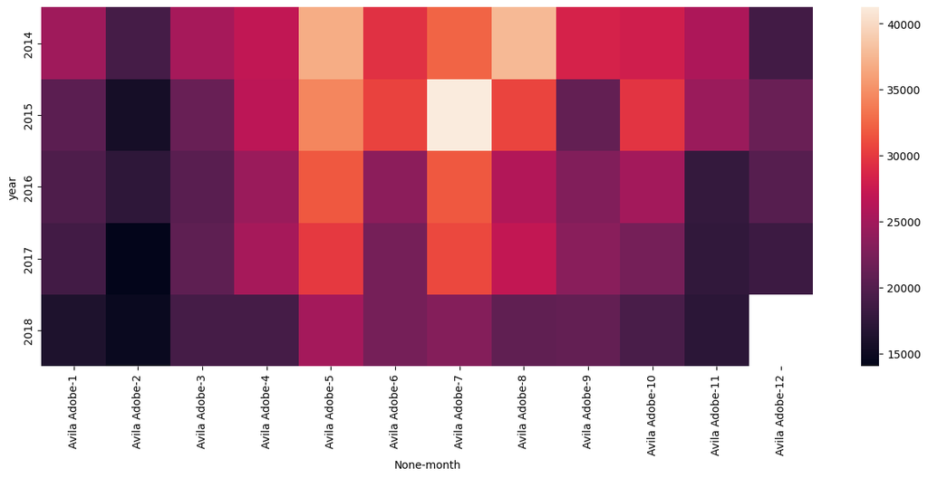

```python
df2 = df.groupby(['month', 'year']).max().unstack(level=0)
plt.figure(figsize=(16,6))
sns.heatmap(data=df2)
plt.show()
```

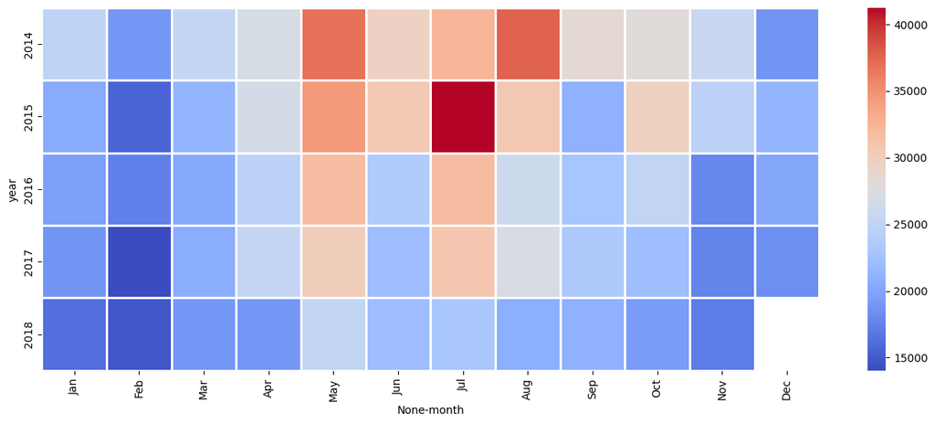

```python
plt.figure(figsize=(16,6))
sns.heatmap(data=df2, cmap="coolwarm", linewidths=1, square=False)
xticks_labels = ['Jan', 'Feb', 'Mar', 'Apr', 'May', 'Jun',
                'Jul', 'Aug', 'Sep', 'Oct', 'Nov', 'Dec']
plt.xticks(np.arange(12) + .5, labels=xticks_labels)
plt.show()
```

### 1. **`cmap`** (Color Map) qiymatlari:

`cmap` parametri rang palitrasini belgilaydi, va Seaborn va Matplotlib kutubxonalari turli xil rang palitralarini taqdim etadi. Eng keng tarqalganlari:

#### Matplotlib-ning rang palitralari:

- **`'viridis'`**: To'liq rangli palitra (yashil, sariq, ko'k, binafsha). Odatda, yaxshilab kontrastni ta'minlaydi.
- **`'plasma'`**: Sariqdan binafsha ranggacha.
- **`'inferno'`**: Issiq ranglar palitrasi, qora, qizil va sariq tonlarda.
- **`'magma'`**: Ko'kdan pushti ranglargacha bo'lgan palitra.
- **`'cividis'`**: Ko'k va sariq ranglardan iborat kontrastli palitra.

#### RANGLAR PALITRASI:

- **`'YlGnBu'`**: Yellow-Green-Blue (sariq, yashil, ko'k).
- **`'coolwarm'`**: Issiqdan sovuq ranglarga o'zgarish.
- **`'Blues'`**: Barcha ranglar ko'k tonlarida.
- **`'Purples'`**: Barcha ranglar binafsha tonlarida.
- **`'RdBu'`**: Qizil va ko'k tonlarda.
- **`'PiYG'`**: Pink-to-Green (pushti-yashil).
- **`'Set1'`, `'Set2'`, `'Set3'`**: Seaborn palitralari, bir nechta ranglarni ifodalaydi.
- **`'RdYlGn'`**: Red-Yellow-Green (qizil, sariq, yashil).

#### boshqa palitrlar:

- **`'binary'`**: Faqat qora va oq ranglar.
- **`'Greens'`**: Yashil rang palitrasi.
- **`'Oranges'`**: To'q sariq rang palitrasi.
- **`'Purples'`**: Binafsha rang palitrasi.
- **`'Spectral'`**: Yaxshi ko'rinadigan ranglar to'plami.

To'liq rang palitrasi ro'yxatini, siz quyidagi manzilda topishingiz mumkin:

- [Matplotlib color maps documentation](https://matplotlib.org/stable/tutorials/colors/colormaps.html)

### 2. **`square`** qiymati:

`square` parametri faqat **True** yoki **False** qiymatlarni oladi.

- **True**: Har bir katak **kvadrat** shaklida bo'ladi.
- **False**: Har bir katak tasvirning o'lchamiga qarab shaklini o'zgartiradi.

**`square`** parametri **True** yoki **False** qiymatlarini oladi va heatmapning kataklari shaklini qanday ko'rsatishini belgilaydi. Quyida misollar keltirilgan.

### 1. **`square=True`** (Kataklar kvadrat shaklida bo'ladi):

Agar **`square=True`** deb belgilasangiz, `heatmap`ning kataklari har doim kvadrat shaklida bo'ladi. Bu, tasvir o'qi bo'yicha (x va y o'qlari) teng masofada bo'lishini ta'minlaydi.

#### Misol:

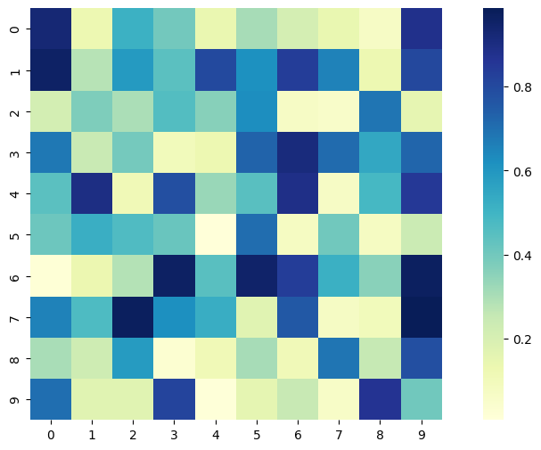

```python
plt.figure(figsize=(12, 6))
# Tasodifiy ma'lumotlar
data = np.random.rand(10, 10)

# Heatmap yaratish, square=True
sns.heatmap(data, square=True, cmap="YlGnBu")
plt.show()
```

- **Kataklar**: har biri **kvadrat** shaklida bo'ladi, ya'ni kenglik va balandlik teng bo'ladi.
- **`square=True`** shuni ta'minlaydi.

### 2. **`square=False`** (Kataklar to'liq o'lchamga qarab bo'ladi):

Agar **`square=False`** deb belgilasangiz, kataklar **kenglik** va **balandlik** (o'qlar) orasidagi nisbatga qarab o'zgaradi. Ya'ni, tasvirning hajmi o'zgarishi bilan kataklarning shakli ham o'zgaradi.

#### Misol:

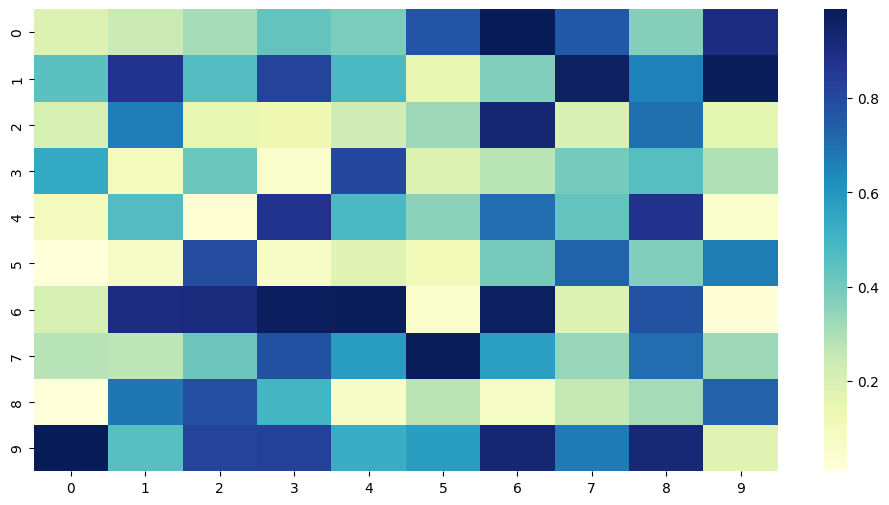

```python
plt.figure(figsize=(12, 6))
# Heatmap yaratish, square=False
sns.heatmap(data, square=False, cmap="YlGnBu")
plt.show()
```

### Natija:

- **Kataklar**: tasvirning o'lchamiga qarab **to'rtburchak** shaklida bo'ladi. Bu, ekran o'lchamiga qarab kenglik va balandlikning farqi bo'lishi mumkin.